# R Notebook

```r
library(tidyverse)
library(modelr)
library(skimr)
```

```r
# load the data
red_wine <- read_csv("data/wine_quality_red.csv")
white_wine <- read_csv("data/wine_quality_white.csv")
```

*Inspect the data*

```r
names(red_wine)
```

```
 [1] "wine_id"              "fixed_acidity"        "volatile_acidity"
 [4] "citric_acid"          "residual_sugar"       "chlorides"
 [7] "free_sulfur_dioxide"  "total_sulfur_dioxide" "density"
[10] "p_h"                  "sulphates"            "alcohol"
[13] "quality"              "region"
```

```r
names(white_wine)
```

```
 [1] "wine_id"              "fixed_acidity"        "volatile_acidity"
 [4] "citric_acid"          "residual_sugar"       "chlorides"
 [7] "free_sulfur_dioxide"  "total_sulfur_dioxide" "density"
[10] "p_h"                  "sulphates"            "alcohol"
[13] "quality"              "region"
```

Names are the same in both data sets.

```r
glimpse(red_wine)
```

```
Rows: 1,599
Columns: 14
$ wine_id              <dbl> 1, 2, 3, 4, 5, 6, 7, 8, 9, 10, 11, 12, 13, 14, 15, 16, 17, 18,…
$ fixed_acidity        <dbl> 74, 78, 78, 112, 74, 74, 79, 73, 78, 75, 67, 75, 56, 78, 89, 8…
$ volatile_acidity     <dbl> 0.700, 0.880, 0.760, 0.280, 0.700, 0.660, 0.600, 0.650, 0.580,…
$ citric_acid          <dbl> 0.00, 0.00, 0.04, 0.56, 0.00, 0.00, 0.06, 0.00, 0.02, 0.36, 0.…
$ residual_sugar       <dbl> 19, 26, 23, 19, 19, 18, 16, 12, 2, 61, 18, 61, 16, 16, 38, 39,…
$ chlorides            <dbl> 0.076, 0.098, 0.092, 0.075, 0.076, 0.075, 0.069, 0.065, 0.073,…
$ free_sulfur_dioxide  <dbl> 11, 25, 15, 17, 11, 13, 15, 15, 9, 17, 15, 17, 16, 9, 52, 51, …
$ total_sulfur_dioxide <dbl> 34, 67, 54, 60, 34, 40, 59, 21, 18, 102, 65, 102, 59, 29, 145,…
$ density              <dbl> 0.9978, 0.9968, 0.9970, 0.9980, 0.9978, 0.9978, 0.9964, 0.9946…
$ p_h                  <dbl> 351, 32, 326, 316, 351, 351, 33, 339, 336, 335, 328, 335, 358,…
$ sulphates            <dbl> 0.56, 0.68, 0.65, 0.58, 0.56, 0.56, 0.46, 0.47, 0.57, 0.80, 0.…
$ alcohol              <dbl> 94, 98, 98, 98, 94, 94, 94, 10, 95, 105, 92, 105, 99, 91, 92, …
$ quality              <dbl> 5.17, 5.04, 5.05, 5.99, 4.94, 5.51, 5.44, 7.46, 6.75, 5.37, 4.…
$ region               <chr> "France", "Italy", "USA", "Italy", "Spain", "Spain", "Italy", …
```

```r
glimpse(white_wine)
```

```
Rows: 4,898
Columns: 14
$ wine_id              <dbl> 1, 2, 3, 4, 5, 6, 7, 8, 9, 10, 11, 12, 13, 14, 15, 16, 17, 18,…
$ fixed_acidity        <dbl> 7, 63, 81, 72, 72, 81, 62, 7, 63, 81, 81, 86, 79, 66, 83, 66, …
$ volatile_acidity     <dbl> 0.27, 0.30, 0.28, 0.23, 0.23, 0.28, 0.32, 0.27, 0.30, 0.22, 0.…
$ citric_acid          <dbl> 0.36, 0.34, 0.40, 0.32, 0.32, 0.40, 0.16, 0.36, 0.34, 0.43, 0.…
$ residual_sugar       <dbl> 20.70, 1.60, 6.90, 8.50, 8.50, 6.90, 7.00, 20.70, 1.60, 1.50, …
$ chlorides            <dbl> 0.045, 0.049, 0.050, 0.058, 0.058, 0.050, 0.045, 0.045, 0.049,…
$ free_sulfur_dioxide  <dbl> 45, 14, 30, 47, 47, 30, 30, 45, 14, 28, 11, 17, 16, 48, 41, 28…
$ total_sulfur_dioxide <dbl> 170, 132, 97, 186, 186, 97, 136, 170, 132, 129, 63, 109, 75, 1…
$ density              <dbl> 1.0010, 0.9940, 0.9951, 0.9956, 0.9956, 0.9951, 0.9949, 1.0010…
$ p_h                  <dbl> 3, 33, 326, 319, 319, 326, 318, 3, 33, 322, 299, 314, 318, 354…
$ sulphates            <dbl> 0.45, 0.49, 0.44, 0.40, 0.40, 0.44, 0.47, 0.45, 0.49, 0.45, 0.…
$ alcohol              <dbl> 88, 95, 101, 99, 99, 101, 96, 88, 95, 11, 12, 97, 108, 124, 97…
$ quality              <dbl> 6.05, 5.65, 6.32, 5.96, 6.08, 5.87, 6.16, 5.89, 5.63, 5.94, 4.…
$ region               <chr> "Australia", "France", "USA", "Spain", "USA", "USA", "France",…
```

Both data sets have the same variable names and data types.

We should join the two tables with `bind_rows()`.

```r
wine <- bind_rows(red_wine, white_wine)
```

*Alias*

Are there any aliases in the dataset?

```r
alias(quality ~., data = wine)
```

```
Model :
quality ~ wine_id + fixed_acidity + volatile_acidity + citric_acid +
    residual_sugar + chlorides + free_sulfur_dioxide + total_sulfur_dioxide +
    density + p_h + sulphates + alcohol + region
```

No aliases.

*Categorical variables & tidy-up*

```r
# NAs in the dataset
colSums(is.na(wine))
```

```
             wine_id        fixed_acidity     volatile_acidity          citric_acid
                   0                    0                    0                    0
      residual_sugar            chlorides  free_sulfur_dioxide total_sulfur_dioxide
                   0                    0                    0                    2
             density                  p_h            sulphates              alcohol
                   0                    0                    0                    0
             quality               region
                   0                    0
```

Only 2 `NA` observations from ~6,500.

Remove `region` as a variable. It doesn’t characterise each of the wines and is too generic to be of value.

```r
wine_trim <- wine %>%
  select(-region, -wine_id) %>%
  drop_na() # remove NAs
```

Use `skim()` function to examine dataset.

```r
wine_trim %>%
  skim() %>%
  view()
```

- `p_h` has values in excess of 14 and heavily left-skewed
- `quality` values are within the expected range
- `alcohol` has values in excess of 100abv (which cannot be correct) and is heavily right-skewed.
- all other variables are right-skewed

Plot `p_h`:

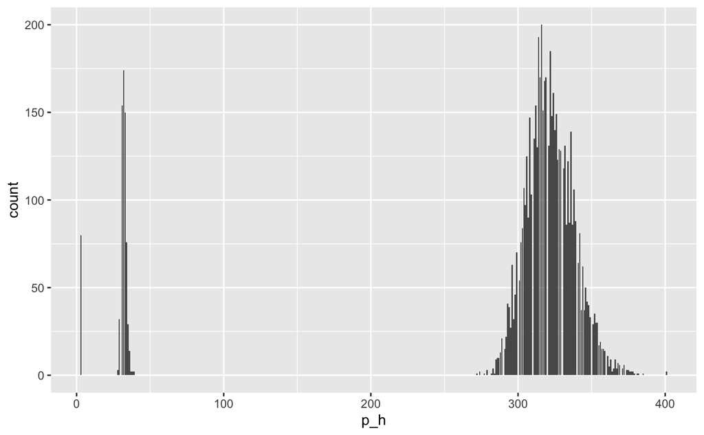

```r
wine_trim %>%
  ggplot() +
  aes(x = p_h) +
  geom_bar()
```

Something is amiss with the `p_h` data. It should be in the range 0 - 14 but the vast majority of the values are between 300 to 400. Consider log transformation of existing variable.

For `quality`, cannot convert to data type `factor` as the dependent variable cannot be categorical.

All the numerical variables are skewed (most to the right) and should be log transformed for linear regression.

Variable `citric acid` has zero values which produce `inf` results when log transformed so have added small positive value (1) to each value prior to log transformation.

```r
wine_trim <- wine_trim %>%
  mutate(log_fixed_acidity = log(fixed_acidity)) %>%
  mutate(log_volatile_acidity = log(volatile_acidity)) %>%
  mutate(log_citric_acid = log(citric_acid + 1)) %>%
  mutate(log_residual_sugar = log(residual_sugar)) %>%
  mutate(log_chlorides = log(chlorides)) %>%
  mutate(log_free_sulfur_dioxide = log(free_sulfur_dioxide)) %>%
  mutate(log_total_sulfur_dioxide = log(total_sulfur_dioxide)) %>%
  mutate(log_density = log(density)) %>%
  mutate(log_p_h = log(p_h)) %>%
  mutate(log_sulphates = log(sulphates)) %>%
  mutate(log_alcohol = log(alcohol)) %>%
  select(-c(fixed_acidity, volatile_acidity, citric_acid, residual_sugar, chlorides,
            free_sulfur_dioxide, total_sulfur_dioxide, sulphates, density, p_h, alcohol))
```

View histogram of variables with skimr:

```r
wine_trim %>%
  skim() %>%
  view()
```

*Issues:*

Distribution of variables after transformation is much improved although `log_density`, `log_ph` and `log_alcohol` all remain badly skewed. Have tried other transformations of these variables (reciprocal and square root) but to no avail. Have decided to remove them before building the model.

```r
# remove skewed variables
wine_trim <- wine_trim %>%
  select(-c(log_density, log_p_h, log_alcohol))
```

*Model build*

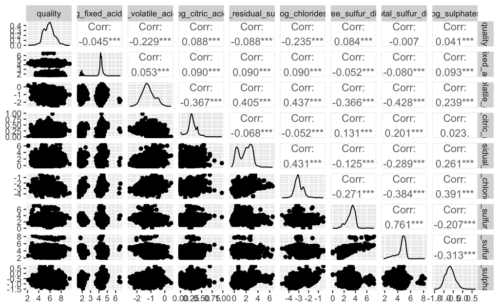

```r
ggpairs(wine_trim)
```

*First predictor*

There appears to be (an albeit weak) correlation between `quality` and `log_volatile_acidity` and `log_chlorides`:

mod1a - `log_volatile_acidity` mod1b - `log_chlorides`

```r
mod1a <- lm(quality ~ log_volatile_acidity, data = wine_trim)
mod1b <- lm(quality ~ log_chlorides, data = wine_trim)
```

*diagnostic plots*

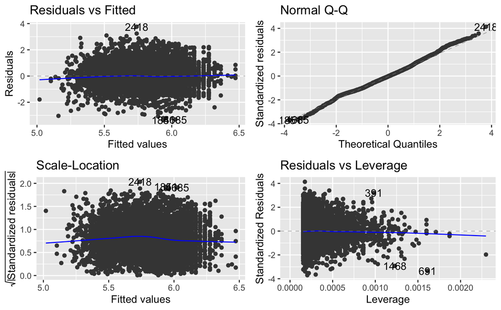

```r
autoplot(mod1a)
```

residual vs fitted - looks fine as the residuals appear randomly scattered around zero normal Q-Q - again looks fine as residuals stick close to line and so appear normally distributed scale/location - fixed width band plot of residuals which is fine

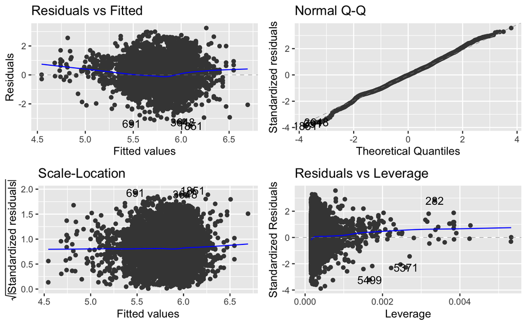

```r
autoplot(mod1b)
```

again, these plots are similar to `mod1a` plots and appear fine.

*summary statistics*

```r
summary(mod1a)
```

```
Call:
lm(formula = quality ~ log_volatile_acidity, data = wine_trim)

Residuals:
    Min      1Q  Median      3Q     Max
-3.3675 -0.6263 -0.0299  0.5615  3.7601

Coefficients:
                     Estimate Std. Error t value Pr(>|t|)
(Intercept)           5.24192    0.03236  161.97   <2e-16 ***
log_volatile_acidity -0.48738    0.02570  -18.97   <2e-16 ***
---
Signif. codes:  0 ‘***’ 0.001 ‘**’ 0.01 ‘*’ 0.05 ‘.’ 0.1 ‘ ’ 1

Residual standard error: 0.9089 on 6493 degrees of freedom
Multiple R-squared:  0.05249,   Adjusted R-squared:  0.05235
F-statistic: 359.7 on 1 and 6493 DF,  p-value: < 2.2e-16
```

intercept = 5.242 r^2 = 0.05249 rse = 0.9089 although statistically significant, `log_volatile_acidity` explains very little of the variation in quality

```r
summary(mod1b)
```

```
Call:
lm(formula = quality ~ log_chlorides, data = wine_trim)

Residuals:
    Min      1Q  Median      3Q     Max
-3.5275 -0.6130 -0.0202  0.5643  3.2379

Coefficients:
              Estimate Std. Error t value Pr(>|t|)
(Intercept)    4.29247    0.07894   54.38   <2e-16 ***
log_chlorides -0.50983    0.02612  -19.52   <2e-16 ***
---
Signif. codes:  0 ‘***’ 0.001 ‘**’ 0.01 ‘*’ 0.05 ‘.’ 0.1 ‘ ’ 1

Residual standard error: 0.9075 on 6493 degrees of freedom
Multiple R-squared:  0.05541,   Adjusted R-squared:  0.05526
F-statistic: 380.9 on 1 and 6493 DF,  p-value: < 2.2e-16
```

intercept = 4.292 r^2 = 0.05541 rse = 0.9075 like mod1a, `log_chlorides` is statistically significant but explains very little of the variation in `quality`.

Both predictors have poor r^2 values but the better of the two is `mod1b` so we will choose `log_chlorides` as the first predictor for the model.

Model: quality = 4.29 + (-0.51 * `log_chlorides`)

*Second predictor*

```r
# remove quality and log_chlorides from model
wine_remaining_resid <- wine_trim %>%
  add_residuals(mod1b) %>%
  select(-c(quality, log_chlorides))
```

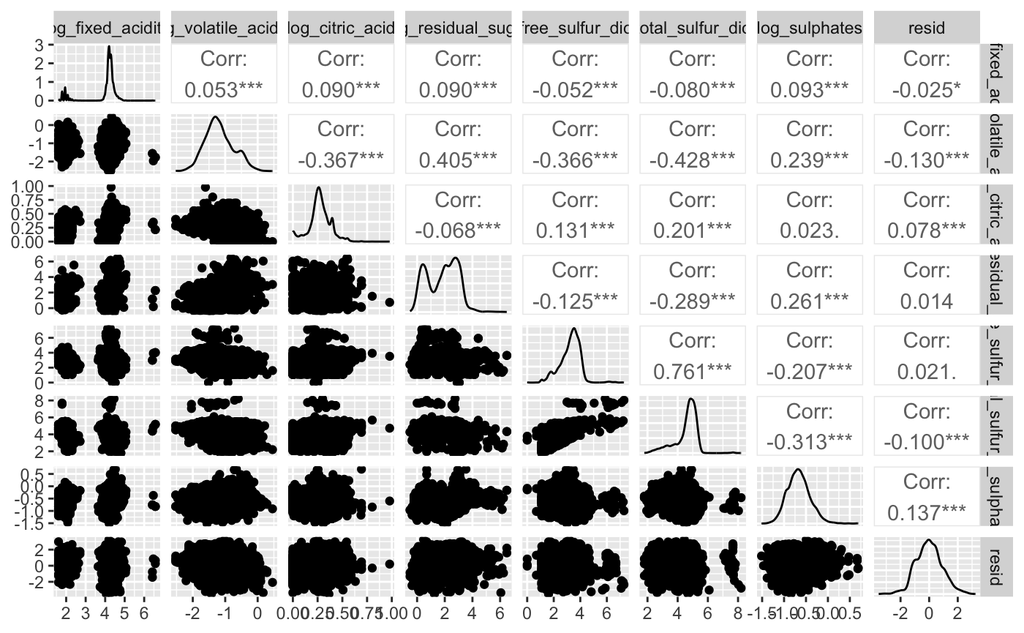

```r
# examine relationship between remaining predictors
ggpairs(wine_remaining_resid)
```

Again, the correlation between the residuals and the remaining predictors is weak. The best of the bunch are:

mod2a - `log_chlorides` + `log_volatile_acidity` mod2b - `log_chlorides` + `log_sulphates`

```r
mod2a <- lm(quality ~ log_chlorides + log_volatile_acidity, data = wine_trim)
mod2b <- lm(quality ~ log_chlorides + log_sulphates, data = wine_trim)
```

*diagnostic plots*

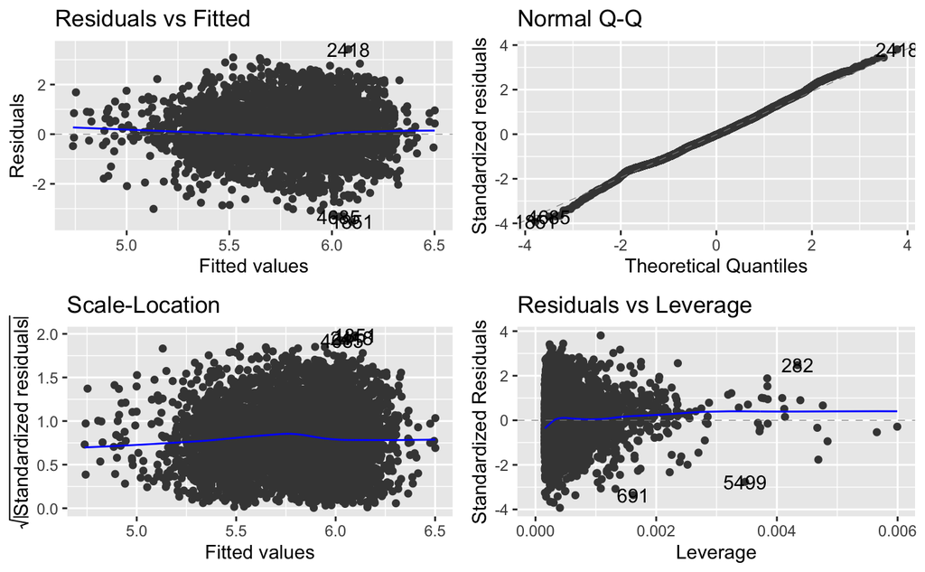

```r
autoplot(mod2a)
```

Very similar to the original plots for mod1a and mod1b, the diagnostic plots look fine

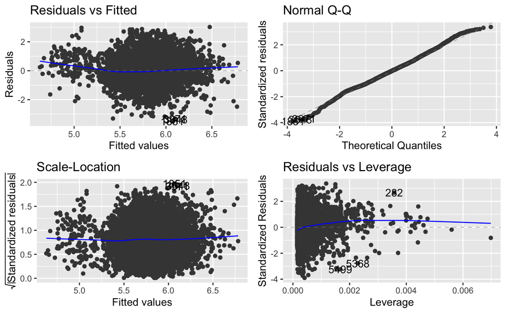

```r
autoplot(mod2b)
```

Again, the plots look fine.

*summary statistics*

```r
summary(mod2a)
```

```
Call:
lm(formula = quality ~ log_chlorides + log_volatile_acidity,
    data = wine_trim)

Residuals:
    Min      1Q  Median      3Q     Max
-3.5282 -0.5986 -0.0292  0.5695  3.4195

Coefficients:
                     Estimate Std. Error t value Pr(>|t|)
(Intercept)           4.34247    0.07823   55.51   <2e-16 ***
log_chlorides        -0.36210    0.02874  -12.60   <2e-16 ***
log_volatile_acidity -0.33192    0.02823  -11.76   <2e-16 ***
---
Signif. codes:  0 ‘***’ 0.001 ‘**’ 0.01 ‘*’ 0.05 ‘.’ 0.1 ‘ ’ 1

Residual standard error: 0.8981 on 6492 degrees of freedom
Multiple R-squared:  0.0751,    Adjusted R-squared:  0.07482
F-statistic: 263.6 on 2 and 6492 DF,  p-value: < 2.2e-16
```

intercept = 4.34 r^2 = 0.0751 rse = 0.8981 like the previous predictors, whilst `log_volatile_acidity` is statistically significant, the r^2 value is very small and is a poor predictor.

```r
summary(mod2b)
```

```
Call:
lm(formula = quality ~ log_chlorides + log_sulphates, data = wine_trim)

Residuals:
    Min      1Q  Median      3Q     Max
-3.4995 -0.6196 -0.0131  0.5622  3.0231

Coefficients:
              Estimate Std. Error t value Pr(>|t|)
(Intercept)    4.27506    0.07808   54.75   <2e-16 ***
log_chlorides -0.64305    0.02807  -22.91   <2e-16 ***
log_sulphates  0.57145    0.04707   12.14   <2e-16 ***
---
Signif. codes:  0 ‘***’ 0.001 ‘**’ 0.01 ‘*’ 0.05 ‘.’ 0.1 ‘ ’ 1

Residual standard error: 0.8975 on 6492 degrees of freedom
Multiple R-squared:  0.07638,   Adjusted R-squared:  0.0761
F-statistic: 268.4 on 2 and 6492 DF,  p-value: < 2.2e-16
```

intercept = 4.28 r^2 = 0.0764 rse = 0.8975 as above, the `log_sulphates` predictor is statistically significant but with such a low r^2 number offers little to the model. That said, it provides more predictive power than `mod2a` so we choose `mod2b` to be the new model.

Model: quality = 4.28 + (-0.64 * `log_chlorides`) + (0.571 * `log_sulphates`)

*Third predictor*

```r
# remove log_sulphates from model
wine_remaining_resid <- wine_trim %>%
  add_residuals(mod2b) %>%
  select(-c(quality, log_chlorides, log_sulphates))
```

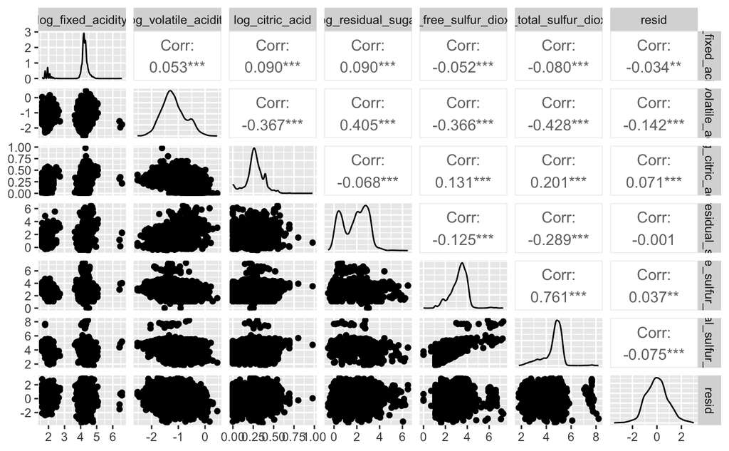

```r
# examine relationship between remaining predictors
ggpairs(wine_remaining_resid)
```

Yet again, the correlation between the residuals and the remaining predictors is weak. The best of the bunch are:

mod3a - `log_chlorides` + `log_sulphates` + `log_volatile_acidity` mod3b - `log_chlorides` + `log_sulphates` + `log_total_sulfur_dioxide`

```r
mod3a <- lm(quality ~ log_chlorides + log_sulphates + log_volatile_acidity, data = wine_trim)
mod3b <- lm(quality ~ log_chlorides + log_sulphates + log_total_sulfur_dioxide, data = wine_trim)
```

*diagnostic plots*

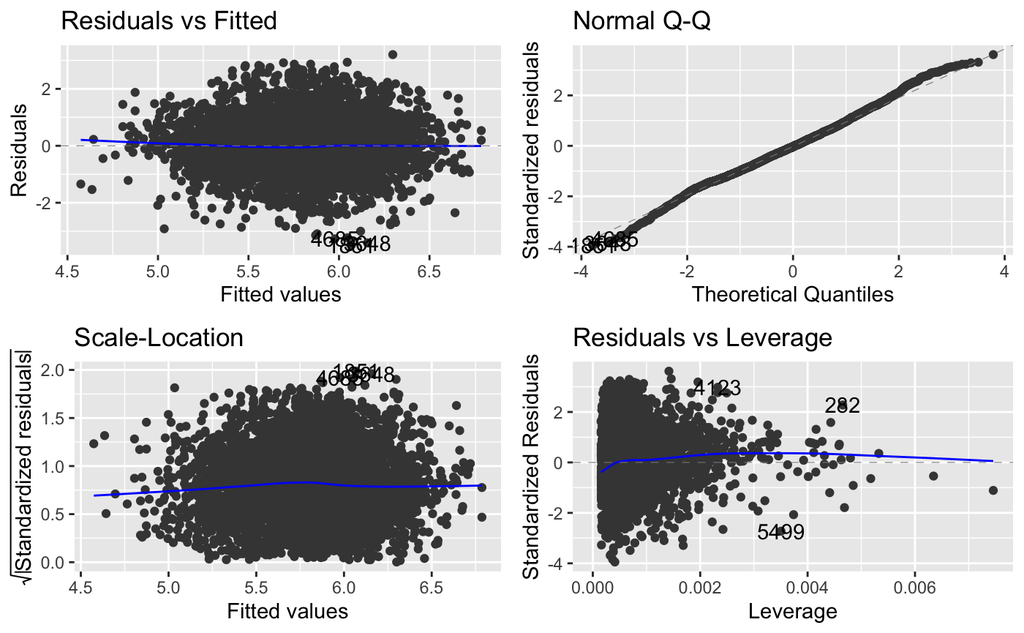

```r
autoplot(mod3a)
```

As with the previous plots, these look fine.

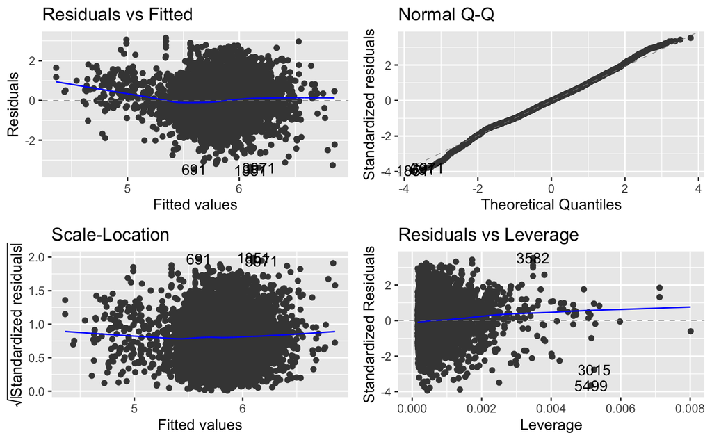

```r
autoplot(mod3b)
```

residual vs fitted: slight smile on the line but nothing major. All other plots look fine.

*summary statistics*

```r
summary(mod3a)
```

```
Call:
lm(formula = quality ~ log_chlorides + log_sulphates + log_volatile_acidity,
    data = wine_trim)

Residuals:
    Min      1Q  Median      3Q     Max
-3.4977 -0.6000 -0.0317  0.5547  3.2028

Coefficients:
                     Estimate Std. Error t value Pr(>|t|)
(Intercept)           4.32816    0.07720   56.06   <2e-16 ***
log_chlorides        -0.49329    0.03002  -16.43   <2e-16 ***
log_sulphates         0.62122    0.04663   13.32   <2e-16 ***
log_volatile_acidity -0.36256    0.02795  -12.97   <2e-16 ***
---
Signif. codes:  0 ‘***’ 0.001 ‘**’ 0.01 ‘*’ 0.05 ‘.’ 0.1 ‘ ’ 1

Residual standard error: 0.8861 on 6491 degrees of freedom
Multiple R-squared:  0.09972,   Adjusted R-squared:  0.0993
F-statistic: 239.7 on 3 and 6491 DF,  p-value: < 2.2e-16
```

intercept = 4.328 r^2 = 0.099 rse = 0.886 like all the others before, this predictor is statistically significant but offer little predictive power

```r
summary(mod3b)
```

```
Call:
lm(formula = quality ~ log_chlorides + log_sulphates + log_total_sulfur_dioxide,
    data = wine_trim)

Residuals:
    Min      1Q  Median      3Q     Max
-3.5295 -0.6129 -0.0104  0.5628  3.1466

Coefficients:
                         Estimate Std. Error t value Pr(>|t|)
(Intercept)               4.56512    0.08911  51.232  < 2e-16 ***
log_chlorides            -0.70169    0.02932 -23.933  < 2e-16 ***
log_sulphates             0.51040    0.04779  10.680  < 2e-16 ***
log_total_sulfur_dioxide -0.11067    0.01656  -6.681 2.56e-11 ***
---
Signif. codes:  0 ‘***’ 0.001 ‘**’ 0.01 ‘*’ 0.05 ‘.’ 0.1 ‘ ’ 1

Residual standard error: 0.8945 on 6491 degrees of freedom
Multiple R-squared:  0.08269,   Adjusted R-squared:  0.08227
F-statistic:   195 on 3 and 6491 DF,  p-value: < 2.2e-16
```

intercept = 4.565 r^2 = 0.083 rse = 0.8945 yet again, whilst statistically significant, the predictor adds little to the model.

Although dire, `mod3a` offers the best results so we adopt `log_volatile_acidity` in to the model.

Model: quality = 4.328 + (-0.493 * `log_chlorides`) + (0.621 * `log_sulphates`) + (-0.363 * `log_volatile_acidity`)